# Question 3

## Is differential expression equal across chromosomes?

Install and import the packages needed to do our analysis

```r
library(pheatmap)
library(edgeR)
```

```r
library(data.table)
library(dplyr)
```

```r
library(magrittr)
```

Next we load all the datasets into r

```r
ESCn1 <- read.csv("/Users/ryan/Desktop/projectcsvs/ESCn1.csv")
ESCn2 <- read.csv("/Users/ryan/Desktop/projectcsvs/ESCn2.csv")
ESCd1 <- read.csv("/Users/ryan/Desktop/projectcsvs/ESCd1.csv")
ESCd2 <- read.csv("/Users/ryan/Desktop/projectcsvs/ESCd2.csv")
```

Next, we create a "keeps" data frame which holds only the data we need for each chromosome. We do this using a for loop instead of doing each of the 21 chromosomes manually

```r
keeps <- c("transcript_id", "chromosome", "TPM")
chrs <- c("1","2","3","4","5",
          "6","7","8","9","10",
          "11","12","13","14",
          "15","16","17","18",
          "19","X","Y")
for (chr in chrs) {
  nam_rep1_d <- paste("ESCd1_chr", chr, sep = "")
  val_rep1_d <- ESCd1[(ESCd1$chromosome==chr),][keeps]
  assign(nam_rep1_d,val_rep1_d)
  nam_rep2_d <- paste("ESCd2_chr", chr, sep = "")
  val_rep2_d <- ESCd2[(ESCd2$chromosome==chr),][keeps]
  assign(nam_rep2_d,val_rep2_d)
  nam_rep1_n <- paste("ESCn1_chr", chr, sep = "")
  val_rep1_n <- ESCn1[(ESCn1$chromosome==chr),][keeps]
  assign(nam_rep1_n,val_rep1_n)
  nam_rep2_n <- paste("ESCn2_chr", chr, sep = "")
  val_rep2_n <- ESCn2[(ESCn2$chromosome==chr),][keeps]
  assign(nam_rep2_n,val_rep2_n)
}
```

For each chromosome, we then merge the non treated replicates and rename the columns

```r
for (chr in chrs) {
  rep1 <- paste("ESCn1_chr", chr, sep = "")
  rep1 <- get(rep1)
  rep2 <- paste("ESCn2_chr", chr, sep = "")
  rep2 <- get(rep2)
  temp <- merge(rep1,rep2, by=c("transcript_id", "chromosome"))
  colnames(temp)[3] <- "TPM_n1"
  colnames(temp)[4] <- "TPM_n2"
  nchr <- paste("n_chr", chr, sep = "")
  assign(nchr,temp)
}
```

Do the same thing for the treated replicates.

```r
for (chr in chrs) {
  rep1 <- paste("ESCd1_chr", chr, sep = "")
  rep1 <- get(rep1)
  rep2 <- paste("ESCd2_chr", chr, sep = "")
  rep2 <- get(rep2)
  temp <- merge(rep1,rep2, by=c("transcript_id", "chromosome"))
  colnames(temp)[3] <- "TPM_d1"
  colnames(temp)[4] <- "TPM_d2"
  dchr <- paste("d_chr", chr, sep = "")
  assign(dchr,temp)
}
```

Now merge these two samples

```r
for (chr in chrs) {
  nam_mrg <- paste("chr", chr, sep = "")
  val_d <- paste("d_chr", chr, sep = "")
  val_d <- get(val_d)
  val_n <- paste("n_chr", chr, sep = "")
  val_n <- get(val_n)
  assign(nam_mrg,merge(val_d,val_n,by=c("transcript_id", "chromosome")))
}
```

Next we have to convert this data into edgeR friendly data, which only takes normalized values. So we remove id and chr and convert into an edgeR object

```r
for (chr in chrs) {
  nam_expr <- paste("expr_chr", chr, sep = "")
  nam_chr <- paste("chr", chr, sep  = "")
  chr <- get(nam_chr)
  assign(nam_expr,chr[-c(1, 2)])
}

## Convert to an edgeR object
#
## do this for every chromosome
#
for (chr in chrs) {
  nam_edgr <- paste("dgeObj_chr", chr, sep = "")
  nam_expr <- paste("expr_chr", chr, sep  = "")
  expr <- get(nam_expr)
  assign(nam_edgr,DGEList(expr))
}
```

EdgeR requires a design matrix for comparing between treated and non treated so we create that here.

```r
design.mat <- cbind(c(1,1,0,0),c(0,0,1,1))
colnames(design.mat) <- c("Case", "Control")
```

Now we need to find the variance for each transcript in order to test for differential expression. To do this we need to first find the dispersion and mean TPM for each transcript. So here we estimate the dispersion for each transcript.

```r
for (chr in chrs) {
  nam_edgr <- paste("dgeObj_chr", chr, sep = "")
  edgr <- get(nam_edgr)
  edgr <- estimateCommonDisp(edgr)
  edgr <- estimateGLMTrendedDisp(edgr)
  edgr <- estimateTagwiseDisp(edgr)
  assign(nam_edgr,edgr)
}
```

Now we can preform the test for differential expression for each chromosome and save the results.

```r
for (chr in chrs) {
  nam_edgr <- paste("dgeObj_chr", chr, sep = "")
  edgr <- get(nam_edgr)
  nam_fit <- paste("fit_chr", chr, sep = "")
  nam_lrt <- paste("lrt.chr", chr, sep = "")
  assign(nam_fit,glmFit(edgr, design.mat))
  fit <- get(nam_fit)
  assign(nam_lrt,glmLRT(fit, coef=2))
}

results <- topTags(lrt.chr1)
results <- as.data.frame(lrt.chr1$table)
results <- results[(results$PValue <= .05),]
results = list()
for (chr in chrs) {
  nam_lrt <- paste("lrt.chr", chr, sep = "")
  lrt <- get(nam_lrt)
  DE_edgr <- as.data.frame(topTags(lrt, n = "Inf"))
  DE_edgr <- DE_edgr[(DE_edgr$FDR <= .05),]
  results <- append(results, nrow(DE_edgr))
}
```

Here is the resulting data frame

```r
#[[1]]
#[1] 5798
#[[2]]
#[1] 7643
#[[3]]
#[1] 4757
#[[4]]
#[1] 5609
#[[5]]
#[1] 6537
#[[6]]
#[1] 4602
#[[7]]
#[1] 7555
#[[8]]
#[1] 4674
#[[9]]
#[1] 5575
#[[10]]
#[1] 4433
#[[11]]
#[1] 6830
#[[12]]
#[1] 3689
#[[13]]
#[1] 3697
#[[14]]
#[1] 3894
#[[15]]
#[1] 3678
#[[16]]
#[1] 3095
#[[17]]
#[1] 5016
#[[18]]
#[1] 2418
#[[19]]
#[1] 3046
#[[20]]
#[1] 3192
#[[21]]
#[1] 105
```

As we can see the number for the 21st chromosome is extremely small compared to the rest. This is because this chromosome is naturally shorter than the rest. As this outlier would mess with our data, we decided to normalize these values by length.

```r
standDE <- c()
for (chr in chrs) {
  nam_rep1_d <- paste("ESCd1_chr", chr, sep = "")
  val_rep1_d <- nrow(ESCd1[(ESCd1$chromosome==chr),])
  assign(nam_rep1_d,val_rep1_d)
  DE_edgr <- as.data.frame(topTags(lrt, n = "Inf"))
  DE_edgr <- DE_edgr[(DE_edgr$FDR <= .05),]
  standDE <- append(standDE, nrow(DE_edgr)/val_rep1_d)
}
```

```r
#[1] 0.011261261 0.008631319 0.013865047 0.012257763 0.010657734 0.012448133 0.007777778 0.014724443 0.011812352
#[10] 0.014714126 0.010692464 0.017658930 0.017009558 0.015930815 0.018505464 0.021229276 0.013368984 0.026929982
#[19] 0.022189349 0.018411362 0.045141874
```

Now we can preform a chi sqauare test to see whether or not the differential expression across all chromosomes is equal or not.

```r
expected <- c(1/21,1/21,1/21,1/21,1/21,1/21,1/21,1/21,1/21,1/21,1/21,1/21,1/21,1/21,1/21,1/21,1/21,1/21,1/21,1/21,1/21)
chisq.test(standDE, p = expected)
```

```
##
##  Chi-squared test for given probabilities
##
## data:  standDE
## X-squared = 0.079456, df = 20, p-value = 1
```

Here are the results

```r
#   Chi-squared test for given probabilities

#data:  standDE
#X-squared = 0.079456, df = 20, p-value = 1
```

Here are the visual models of our data. This barplot shows the data before we standardized it. As stated previously, the last chromosme is an extreme outlier here. This is the reason that we standardized it

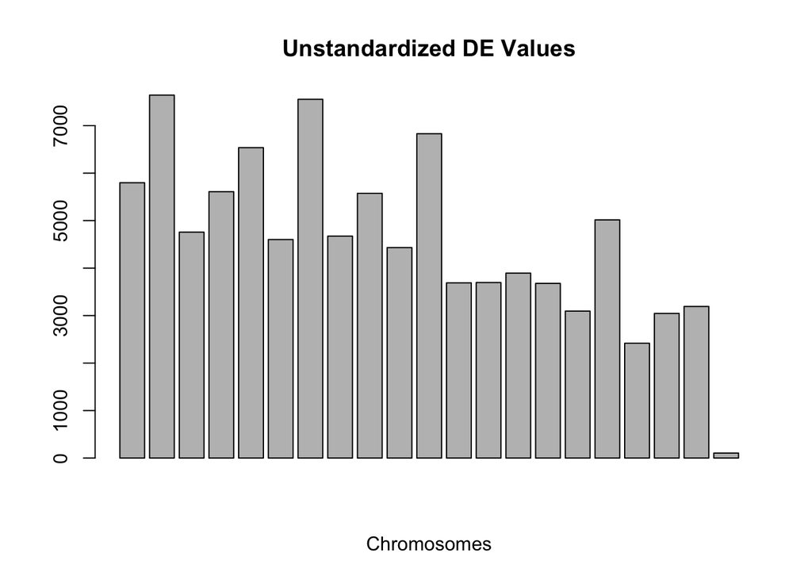

```r
resVector <- c(5798,7643,4757,5609,6537,4602,7555,4674,5575,4433,6830,3689,3697,3894,3678,3095,5016,2418,3046,3192,105)
barplot(resVector, main = "Unstandardized DE Values", xlab = "Chromosomes")
```

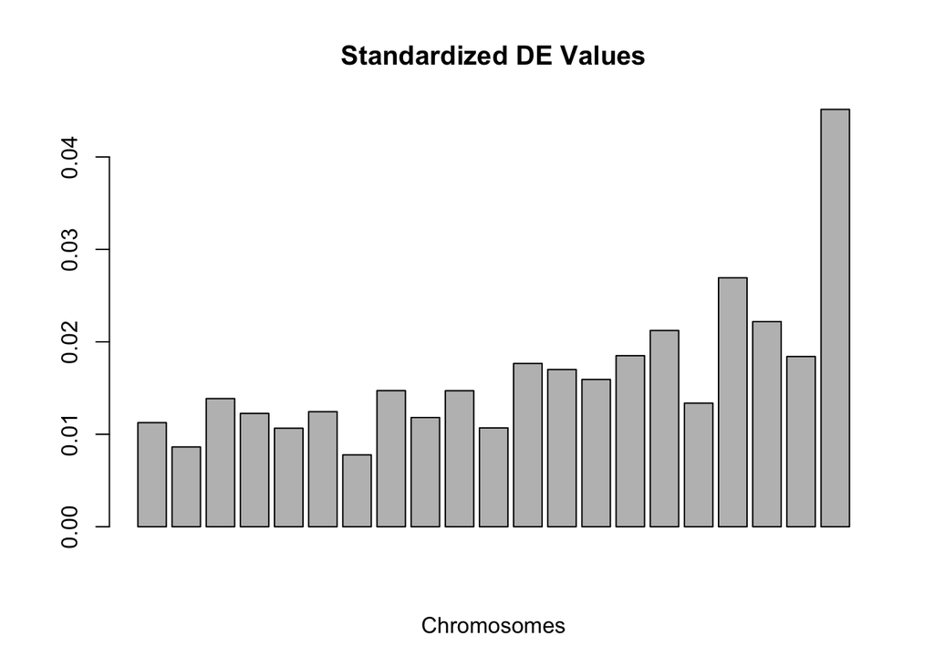

```r
barplot(standDE, main = "Standardized DE Values", xlab = "Chromosomes")
```

To answer question 3 using a quasipoisson model, we loaded the following libraries.

```r
library(ggplot2)
library(data.table)
library(dplyr)
library(magrittr)
```

Next, we made vectors to hold our results, and a list of chromosomes we can iterate through.

```r
chrs <- c("1","2","3","4","5",
          "6","7","8","9","10",
          "11","12","13","14",
          "15","16","17","18",
          "19","X","Y")
standDE <- vector() # This will hold our results, standardized by chromosome length
qp_DEs <- vector()  # This will hold the raw count of results
```

We used the same set of dataframes containing TPM values for each chromosome as we did with the negative binomial model in edgeR. The code used to generate those dataframes is shown below.

```r
keeps <- c("transcript_id", "chromosome", "TPM")
for (chr in chrs) {
  nam_rep1_d <- paste("ESCd1_chr", chr, sep = "")
  val_rep1_d <- ESCd1[(ESCd1$chromosome==chr),][keeps]
  assign(nam_rep1_d,val_rep1_d)
  nam_rep2_d <- paste("ESCd2_chr", chr, sep = "")
  val_rep2_d <- ESCd2[(ESCd2$chromosome==chr),][keeps]
  assign(nam_rep2_d,val_rep2_d)
  nam_rep1_n <- paste("ESCn1_chr", chr, sep = "")
  val_rep1_n <- ESCn1[(ESCn1$chromosome==chr),][keeps]
  assign(nam_rep1_n,val_rep1_n)
  nam_rep2_n <- paste("ESCn2_chr", chr, sep = "")
  val_rep2_n <- ESCn2[(ESCn2$chromosome==chr),][keeps]
  assign(nam_rep2_n,val_rep2_n)
}
### merge the nontreated replicates - rename columns ###
#
## do this for every chromosome
#

for (chr in chrs) {
  rep1 <- paste("ESCn1_chr", chr, sep = "")
  rep1 <- get(rep1)
  rep2 <- paste("ESCn2_chr", chr, sep = "")
  rep2 <- get(rep2)
  temp <- merge(rep1,rep2, by=c("transcript_id", "chromosome"))
  colnames(temp)[3] <- "TPM_n1"
  colnames(temp)[4] <- "TPM_n2"
  nchr <- paste("n_chr", chr, sep = "")
  assign(nchr,temp)
}

### merge the treated replicates - rename columns ###
#
## do this for every chromosome
#
for (chr in chrs) {
  rep1 <- paste("ESCd1_chr", chr, sep = "")
  rep1 <- get(rep1)
  rep2 <- paste("ESCd2_chr", chr, sep = "")
  rep2 <- get(rep2)
  temp <- merge(rep1,rep2, by=c("transcript_id", "chromosome"))
  colnames(temp)[3] <- "TPM_d1"
  colnames(temp)[4] <- "TPM_d2"
  dchr <- paste("d_chr", chr, sep = "")
  assign(dchr,temp)
}

### merge the samples ###
#
## do this for every chromosome
#
for (chr in chrs) {
  nam_mrg <- paste("chr", chr, sep = "")
  val_d <- paste("d_chr", chr, sep = "")
  val_d <- get(val_d)
  val_n <- paste("n_chr", chr, sep = "")
  val_n <- get(val_n)
  assign(nam_mrg,merge(val_d,val_n,by=c("transcript_id", "chromosome")))
}

### clean up ###
rm(list=ls(pattern="d_chr"))
rm(list=ls(pattern="n_chr"))
rm(list=ls(pattern="rep"))
rm(list=ls(pattern="val"))
rm(list=ls(pattern="temp"))

### models take in normalized values only - remove id and chr ###
#
## do this for every chromosome
#
for (chr in chrs) {
  nam_expr <- paste("expr_chr", chr, sep = "")
  nam_chr <- paste("chr", chr, sep  = "")
  chr <- get(nam_chr)
  assign(nam_expr,chr[-c(1, 2)])
}
```

Next we iterated through each chromosome, and identified the number of differentially expressed transcripts on each using a quasipoisson generalized linear model

```r
for (chr in chrs) {
  DEs = vector() ## This holds the DE transcripts for the chromosome

  ### first get relevent TPM matrix ###
  TPM_mat <- paste("expr_chr", chr, sep = "")
  TPM_mat <- get(TPM_mat)

  for (row in 1:nrow(TPM_mat)) {
    tran <- TPM_mat[row,] # grab each set of expression data per transcript ###
    tran <- (as.data.frame(t(as.matrix(tran)))) # transpose the data
    colnames(tran)[1] <- "TPM"
    tran$cell_type <- c(1,1,0,0) # add a column for cell type (1=brain, 0=stem)

    ### We ignore all cases where expression was all zeros ###
    check <- list()
    for (i in 1:nrow(tran)) {
      if (tran[i, 1] != 0) {
        check <- append(check, 1)
      }
    }

    ### Make a quasipoisson logistic model to test if expression level predicts cell type
    if (length(check) > 0) {
      model <- glm(TPM ~ cell_type, data = tran, family = quasipoisson)
    }

    ### If p-value less than .05, we conclude cell type predicts expression ###
    pVal <- (as.matrix(summary(model)$coefficients)[2,4])
    if (as.numeric(pVal) < .05){
      DEs <- append(DEs, rownames(TPM_mat[row,]))
    }
  }

  ### save our raw counts for the chromosome ###
  qp_DEs <- append(qp_DEs,length(DEs))
  ### save our standardized results by dividing by chromosome length ###
  standDE <- append(standDE, length(DEs)/nrow(ESCd1[(ESCd1$chromosome==chr),]))
}
```

To visualize these results, we used bar plots.

Raw counts:

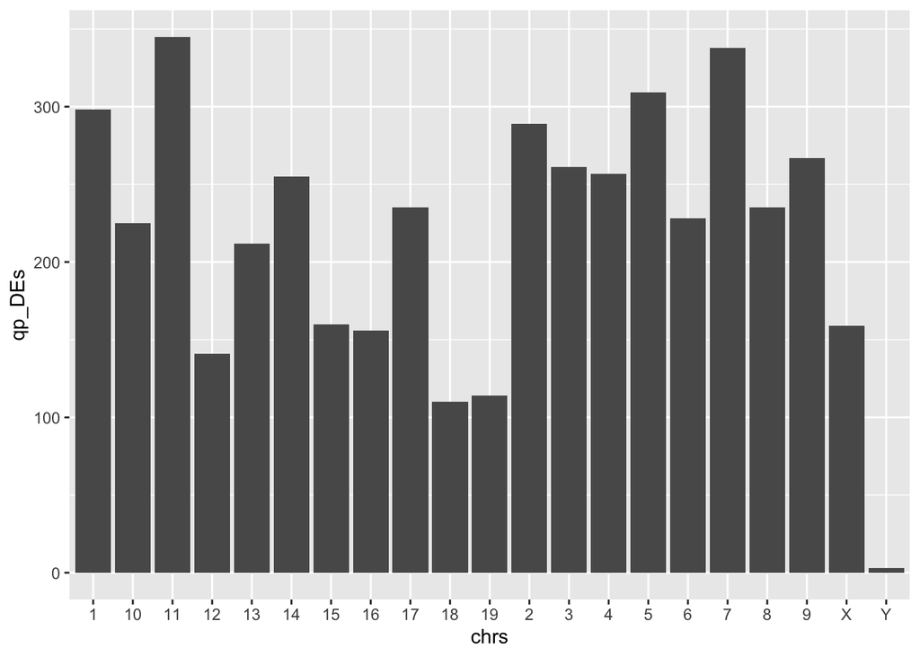

```r
raw_counts <- as.data.frame(qp_DEs)
ggplot(raw_counts, aes(x=chrs, y=qp_DEs),
       xlab("Chromosome"),
       ylab("Number of DE Transcripts")) + geom_bar(stat="identity")
```

Raw counts standardized by chromosome length:

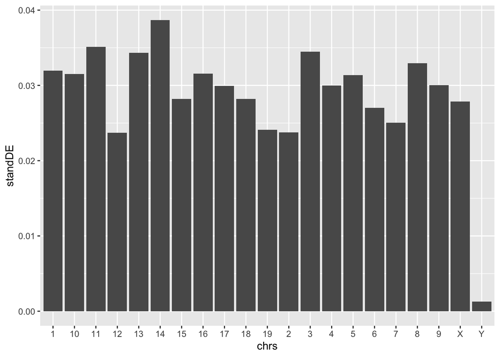

```r
standDE <- as.data.frame(standDE)
ggplot(standDE, aes(x=chrs, y=standDE),
       xlab("Chromosome"),
       ylab("Number of DE Transcripts")) + geom_bar(stat="identity")
```

Chromosome Y seemed to be lower than all other chromosomes in the graphs. To check if the difference is significant we used a Chi Square Goodness of Fit test.

Ho = Differential expression counts are equal across all chromosomes Ha = Differential expression counts are NOT equal across all chromosomes

```r
#our expected probability
expected <- c(1/21,1/21,1/21,1/21,1/21,1/21,
              1/21,1/21,1/21,1/21,1/21,1/21,
              1/21,1/21,1/21,1/21,1/21,1/21,
              1/21,1/21,1/21)
#chi square test
chisq.test(standDE, p = expected)
```

```
##
##  Chi-squared test for given probabilities
##
## data:  standDE
## X-squared = 0.038504, df = 20, p-value = 1
```

Our answer to question 3 using a quasipoisson model is the same as our answer using a negative binomial model.

## Final Outcomes and Analysis

### [Question 1 Report](http://www.itss.brockport.edu/~jlee7/csc435/question1.html)

### [Question 2 Report](http://www.itss.brockport.edu/~jlee7/csc435/question2.html)

### [Homepage](http://www.itss.brockport.edu/~jlee7/csc435/index.html)

### [Question 4 Report](http://www.itss.brockport.edu/~jlee7/csc435/question4.html)

### [Question 5 Report](http://www.itss.brockport.edu/~jlee7/csc435/question5.html)